# Ingresos medios de los hogares por regiones NUTS 2

Aythami Lorenzo Padilla

2026-02-03

[Cuadro de mandos (Enlace público)](https://aythamilorenzo.shinyapps.io/dashboardproyectopersonal/)  
[Cuadro de mandos (Enlace privado ULPGC)](http://10.22.143.222:3838/sample-apps/a2629/DashboardProyectoPersonal.Rmd)

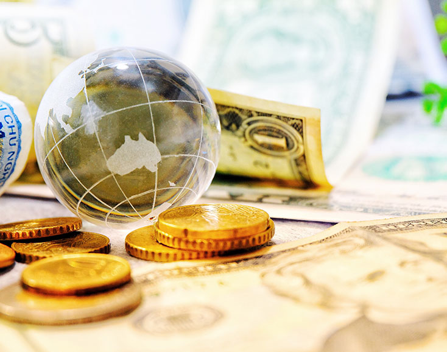

# Introducción

En el marco socioeconómico de la Unión Europea, la cohesión territorial y la reducción de las desigualdades siguen siendo desafíos primordiales. Si bien los indicadores macroeconómicos nacionales suelen acaparar la atención mediática, la renta disponible de los hogares se erige como el indicador más fiel para medir el bienestar real de la ciudadanía, su capacidad de consumo y su nivel de ahorro. En la coyuntura actual, marcada por la recuperación post-pandemia y las tensiones inflacionarias, analizar la evolución de la riqueza familiar no es solo un ejercicio estadístico, sino una herramienta fundamental para evaluar la salud económica real de las familias y la efectividad de las políticas de convergencia europeas.

El problema central que aborda este proyecto radica en que los promedios nacionales a menudo enmascaran profundas disparidades internas. Un análisis limitado al nivel de país (NUTS 0) es insuficiente para comprender la realidad de territorios con dinámicas propias. Por tanto, este estudio desciende al nivel NUTS 2 para visibilizar estas brechas, delimitando el análisis a la evolución comparada de las regiones europeas durante las últimas dos décadas (2000-2022). Específicamente, se pone el foco en la posición relativa de las Comunidades Autónomas españolas, y de manera singular en Canarias como región ultraperiférica, para determinar si existe una convergencia real en términos de renta neta y poder adquisitivo (PPS) frente a los estándares europeos o si, por el contrario, la brecha regional tiende a perpetuarse.

## Estado actual

En el contexto de la economía regional europea, el análisis de la convergencia y la cohesión territorial ha estado tradicionalmente dominado por indicadores agregados a nivel nacional, como el Producto Interior Bruto (PIB). Sin embargo, existe un consenso creciente en la literatura económica y en instituciones como Eurostat sobre las limitaciones de estas métricas para reflejar el bienestar efectivo de la ciudadanía. El “estado del arte” actual se desplaza hacia el estudio de la **Renta Disponible de los Hogares** ajustada por el poder adquisitivo (PPS) y desagregada a niveles territoriales más finos, como el nivel **NUTS 2**, que es la unidad base para la aplicación de las políticas de desarrollo regional de la UE.

#### Justificación y Relevancia del Estudio

La realización de este estudio se justifica por la necesidad de superar la “ceguera de los promedios nacionales”. Estudios precedentes han demostrado que, si bien puede existir convergencia entre países, las **disparidades intrarregionales** a menudo se mantienen o incluso se amplían, especialmente tras choques asimétricos como la crisis financiera de 2008 o la pandemia de COVID-19.

En el caso específico de **España**, la literatura identifica una persistente dualidad norte-sur y una brecha significativa entre las regiones capitalinas/industriales y las periféricas. Este proyecto cobra especial relevancia y oportunidad al centrar el foco en:

- **La realidad granular:** Analizar la evolución de regiones específicas como **Canarias** (Región Ultraperiférica) permite evaluar si los mecanismos de compensación europeos están logrando una convergencia real en el nivel de vida o si existe un desacople estructural respecto al núcleo de la UE.
- **Más allá del PIB:** Al integrar variables como el **Ahorro Neto**, la **Presión Fiscal** y la **Inversión**, este estudio ofrece una visión multidimensional del bienestar que va más allá de la mera producción económica.
- **Contexto temporal crítico:** El periodo de estudio (2000-2022) es idóneo para analizar la resiliencia regional a largo plazo, abarcando ciclos completos de expansión y recesión, lo que permite modelar tendencias futuras con mayor robustez.

## Motivación

La elección de esta temática nace de una proyección personal y profesional orientada hacia el contexto internacional. La aspiración de desarrollar una futura carrera laboral o académica fuera de las fronteras nacionales exige una comprensión profunda y objetiva del entorno socioeconómico europeo. En este sentido, el análisis de datos no se plantea aquí solo como un ejercicio académico, sino como una herramienta fundamental para evaluar la calidad de vida real y las oportunidades estructurales que ofrecen los distintos países miembros, trascendiendo las percepciones generales para basar decisiones futuras en indicadores económicos sólidos.

Asimismo, este proyecto responde a un interés intrínseco por la economía y el análisis macroeconómico. La oportunidad de diseccionar la posición relativa de España frente a sus socios europeos, así como de investigar sus propias disparidades internas a nivel regional, constituye un desafío analítico estimulante. El objetivo último es transformar los datos brutos de Eurostat en conocimiento accionable que permita entender mejor las dinámicas de convergencia, riqueza y bienestar que definen el escenario económico actual.

## Objetivos

El objetivo principal de este proyecto es realizar un análisis comparativo y evolutivo de indicadores económicos como la **renta neta disponible** de los hogares en Europa durante el periodo 2000-2022, trascendiendo los indicadores macroeconómicos nacionales para descender a un nivel regional (**NUTS 2**). Se busca evaluar la calidad de vida económica real, identificando patrones de convergencia o divergencia entre los estados miembros y dentro de España.

Para alcanzar este propósito global, se establecen los siguientes objetivos específicos:

- **Evaluar el posicionamiento de España en la UE:** Determinar la situación real del bienestar económico español en términos de poder adquisitivo (PPS) comparado con las potencias centrales (como Alemania o Benelux) y sus pares mediterráneos.
- **Analizar la disparidad regional interna:** Cuantificar la brecha económica dentro de España, poniendo el foco en la situación de **Canarias** como región ultraperiférica frente a los polos económicos nacionales (Madrid, País Vasco y Navarra).
- **Examinar la estructura de ingresos y gastos:** Comprender la relación entre la generación de riqueza (Ingreso Primario), la intervención del Estado (Presión Fiscal y Prestaciones) y la capacidad resultante de Ahorro de las familias.
- **Modelar tendencias futuras:** Aplicar técnicas de predicción estadística (modelos ARIMA) para anticipar la evolución de la renta neta y la carga impositiva en el horizonte 2030, permitiendo vislumbrar si la brecha económica tiende a cerrarse o a perpetuarse.

# Aportaciones del trabajo

## Principales aportaciones

La realización de este proyecto ha permitido generar valor en tres dimensiones fundamentales: la tecnológica (herramienta), la metodológica (tratamiento del dato) y la analítica (conocimiento económico).

#### 1. Democratización del Acceso a Datos Complejos (La Herramienta)

Una de las aportaciones más tangibles es el desarrollo y despliegue de un **Cuadro de Mandos Interactivo (Dashboard).** Los datos de Eurostat, aunque públicos, suelen ser inaccesibles para el usuario no técnico debido a su estructura compleja y fragmentada.Este proyecto aporta una herramienta centralizada que permite a cualquier usuario —sin conocimientos de programación— explorar dinámicamente la realidad económica europea. La implementación de selectores jerárquicos (País $\to$ Región), la conversión automática de unidades y la visualización reactiva transforman una base de datos estática en un sistema de soporte a la decisión.

#### 2. Visibilidad de la Disparidad Regional (El Enfoque NUTS 2)

Frente a los estudios tradicionales que se limitan a comparar el PIB nacional, este trabajo aporta una **disección granular de la desigualdad.** Al descender al nivel NUTS 2, se ha evidenciado empíricamente que la “marca España” enmascara realidades económicas divergentes. El estudio aporta una cuantificación precisa de la brecha entre las regiones motoras (Madrid, País Vasco) y las regiones rezagadas, con especial énfasis en la situación de vulnerabilidad estructural de **Canarias.** Se ha demostrado que la convergencia regional no es automática y que la insularidad y la estructura productiva condicionan severamente la capacidad de ahorro y la renta disponible.

#### 3. Modelado de la Estructura Económica (Validación Estadística)

Desde una perspectiva analítica, el trabajo aporta evidencia estadística robusta sobre la estructura de los estados de bienestar europeos.

- Mediante el **Análisis de Componentes Principales (PCA)**, se ha simplificado la complejidad económica, demostrando que la varianza entre regiones es unidimensional: la riqueza arrastra consigo todos los demás indicadores (inversión, ahorro, gasto).
- A través de modelos de regresión, se ha desmitificado la presión fiscal, aportando la conclusión de que la carga impositiva en España es coherente con su nivel de renta, refutando la idea de una anomalía fiscal comparada con sus socios europeos.

#### 4. Proyección de Escenarios Futuros (Anticipación)

Finalmente, la aplicación de modelos **ARIMA** aporta una visión prospectiva que trasciende el análisis histórico. Se ofrece una estimación fundamentada de la evolución de la renta y la fiscalidad hasta 2030, identificando alertas tempranas de estancamiento en regiones específicas (como las Ciudades Autónomas) y proporcionando un marco de referencia cuantitativo para evaluar el éxito o fracaso de futuras políticas de cohesión.

## Alineamiento con los objetivos de desarrollo sostenible

Grado de relación del proyecto con los ODS

| ODS | No procede | Bajo | Medio | Alto |
| --- | --- | --- | --- | --- |
| 1 Fin de la Pobreza |  |  |  | X |
| 2 Hambre cero | X |  |  |  |
| 3 Salud y Bienestar |  | X |  |  |
| 4 Educación de calidad | X |  |  |  |
| 5 Igualdad de género |  | X |  |  |
| 6 Agua limpia y saneamiento | X |  |  |  |
| 7 Energía Asequible y no contaminante | X |  |  |  |
| 8 Trabajo decente y crecimiento económico |  |  | X |  |
| 9 Industria, Innovación e Infraestructuras | X |  |  |  |
| 10 Reducción de las desigualdades |  |  |  | X |
| 11 Ciudades y comunidades sostenibles | X |  |  |  |
| 12 Producción y consumo sostenibles | X |  |  |  |
| 13 Acción por el clima | X |  |  |  |
| 14 Vida submarina | X |  |  |  |
| 15 Vida de ecosistemas terrestres | X |  |  |  |
| 16 Paz, justicia e instituciones sólidas | X |  |  |  |
| 17 Alianzas para lograr objetivos |  | X |  |  |

#### Justificación del alineamiento

El proyecto presenta una vinculación directa y **Alta** con el **ODS 1 (Fin de la Pobreza)** y el **ODS 10 (Reducción de las Desigualdades).** El análisis de la Renta Disponible Neta ($\text{B6N}$) y su distribución geográfica a nivel NUTS 2 permite identificar con precisión las brechas de riqueza entre las regiones europeas y las disparidades internas en España (como el caso de Canarias). Al visibilizar la divergencia económica y la capacidad real de los hogares, el estudio aporta la base empírica necesaria para evaluar la cohesión territorial.

Asimismo, existe una relación **Media** con el **ODS 8 (Trabajo Decente y Crecimiento Económico),** dado que se analizan indicadores estructurales como la Remuneración de Asalariados ($\text{D1}$) y el Ingreso Primario ($\text{B5N}$), los cuales actúan como termómetros de la productividad y la calidad del empleo regional.

Finalmente, se asigna un nivel **Bajo** a los **ODS 3 (Salud y Bienestar)** y **ODS 5 (Igualdad de Género).** Aunque el nivel de renta es un determinante social de la salud y las prestaciones sociales ($\text{D62}$) incluyen ayudas familiares, el dataset utilizado no permite un desglose específico por género ni métricas sanitarias directas, quedando su impacto en un plano indirecto o contextual. El **ODS 17** se justifica por el uso y promoción de datos abiertos (Open Data) de instituciones europeas.

# Desarrollo

## Herramientas empleadas

El desarrollo de este proyecto se ha sustentado en un ecosistema de herramientas de código abierto, seleccionadas por su robustez en el análisis estadístico, su capacidad de visualización y su flexibilidad para el desarrollo de aplicaciones web interactivas.

#### R y RStudio: El Núcleo del Análisis

Como lenguaje de programación principal se ha utilizado **R**, debido a su posición dominante en el ámbito de la estadística y la ciencia de datos. Su capacidad nativa para manejar grandes volúmenes de datos estructurados y su inmensa colección de paquetes especializados lo convierten en la elección óptima frente a otras alternativas.

El entorno de desarrollo integrado (IDE) elegido ha sido **RStudio**. Su interfaz facilita la gestión simultánea de scripts, consolas, visualización de gráficos y control de entornos, lo cual ha sido crucial para iterar rápidamente en el análisis exploratorio y la depuración del código.

#### Librerías Principales

El proyecto se apoya en un conjunto de librerías clave que han permitido transformar los datos brutos en conocimiento visualizable:

- `tidyverse` **(dplyr, tidyr, ggplot2):** La columna vertebral del proyecto. Se ha empleado para la manipulación, limpieza y transformación de los datos (data wrangling), así como para la generación de gráficos estáticos de alta calidad mediante la gramática de gráficos.
- `eurostat`: Fundamental para la ingesta automatizada y normalizada de los datos de población directamente desde la base de datos oficial de la Comisión Europea, garantizando la reproducibilidad del análisis.
- `plotly` y `highcharter`: Utilizadas para dotar de interactividad avanzada a las visualizaciones, permitiendo al usuario final explorar los datos (tooltips, zoom, filtrado) de manera dinámica dentro del cuadro de mandos.
- `gganimate`: Esta librería ha sido clave para incorporar la dimensión temporal de forma dinámica, permitiendo la creación de gráficos animados que ilustran la evolución del ranking de renta por países año a año, facilitando la comprensión de las tendencias de convergencia.
- `leaflet` y `geojsonio`: Esenciales para el componente geoespacial. Han permitido la lectura de archivos GeoJSON y el renderizado de mapas coropléticos interactivos, integrando las geometrías NUTS con los indicadores económicos.
- `fpp3` **(fable, tsibble):** Empleada para el análisis avanzado de series temporales. Ha facilitado la conversión de datos a estructuras temporales (`tsibble`), el tratamiento de huecos (`fill_gaps`) y la generación de modelos predictivos **ARIMA.**
- `DT` y `kableExtra`: Utilizadas para la presentación tabular de los datos. `DT` ha permitido crear tablas interactivas con paginación y búsqueda en el cuadro de mandos, mientras que `kableExtra` se ha usado para el formateo estático de tablas en la memoria.
- `openxlsx` y `googlesheets4`: Empleadas para la interoperabilidad con fuentes de datos externas. openxlsx ha permitido la ingesta de metadatos locales (relación con los ODS), mientras que googlesheets4 ha posibilitado la conexión en tiempo real con la hoja de cálculo de seguimiento del proyecto alojada en la nube.
- `flexdashboard` y `shiny`: Estas librerías han sido la base para la construcción del producto final. `flexdashboard` ha permitido estructurar el análisis en un layout de cuadro de mandos (dashboard) responsivo, mientras que `shiny` ha inyectado la lógica reactiva necesaria (inputs dinámicos, renderizado condicional) para que los filtros y selectores controlen los gráficos en tiempo real.
- `utilidades.r`: También es importante mencionar el script llamado `utilidades.r`, ya que a pesar de no ser una librería, ha permitido el uso de funciones que mejoran enormemente la facilidad y calidad del análisis, funciones tales como aquellas que hacen posible la creación de **mapas coropléticos, matrices de correlación o gráficos de predicciones animados con intervalos de confianza** entre otras.

#### Servidor Shiny del DIS

Para la difusión y acceso público del cuadro de mandos, se ha optado por el despliegue en el servidor **Shiny del Departamento de Informática y Sistemas (DIS).** Esta infraestructura permite alojar la aplicación de manera estable, asegurando que el procesamiento reactivo de los datos (como los modelos ARIMA o los filtros dinámicos de regiones) se ejecute en el servidor y se sirva al usuario final a través de cualquier navegador web.

## Metodología

Utilizaremos la metodología de desarrollo CRISP-DM (Cross Industry Standard Process for Data Mining) que es un marco ampliamente utilizado para proyectos de Ciencias de Datos. En la siguiente figura se presenta un diagrama con las diferentes fases de esta metodología que a continuación describimos con más detalle:

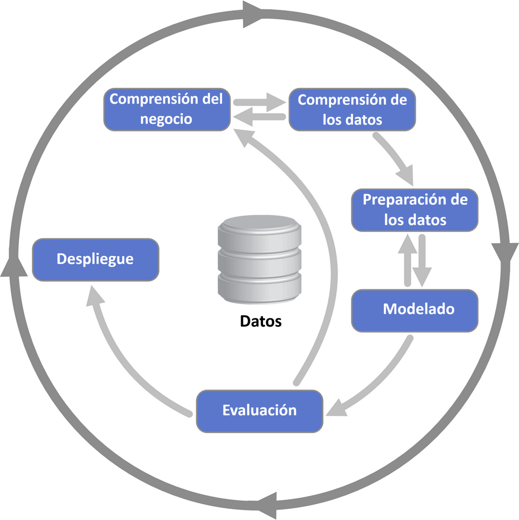

*Diagrama metodología de desarrollo CRISP-DM*

- **Comprensión del negocio**. Se plantean los objetivos del proyecto y la búsqueda de información y datos.
- **Comprensión de los datos**. Se analiza la estructura y organización de los datos obtenidos. Se identifican posible problemas como datos faltantes, outliers o inconsistencias.
- **Modelado**. Selección y aplicación de los modelos adecuados para analizar los datos
- **Evaluación**. Evaluar si el modelo responde a las preguntas de investigación, comparación con otros métodos
- **Despliegue**. Comunicación del trabajo en una memoria y diseño y elaboración de un cuadro de mandos para presentar los resultados de forma eficaz y atractiva.

Es importante observar que esta metodología es iterativa, es decir que los resultados obtenidos en algunas de las fases puede afectar al desarrollo de fases anteriores.

A continuación se describirá en detalle como se han abordado cada una de las fases del desarrollo del proyecto siguiendo esta metodología.

## Comprensión del negocio

El proceso de búsqueda de información se centró exclusivamente en el repositorio oficial de **Eurostat**, dada su fiabilidad y estandarización para comparativas a nivel europeo. La selección de los conjuntos de datos finales fue el resultado de un proceso iterativo de evaluación y filtrado:

- **Dataset Económico Principal:** Inicialmente, se exploraron diversos candidatos para la obtención de los indicadores de renta. Se descartó una primera opción preliminar debido a la **alta escasez de datos (sparsity)** y a la falta de cobertura histórica consistente para las regiones objetivo del estudio, específicamente para España y la región NUTS 2 de Canarias. Esto obligó a realizar una búsqueda más exhaustiva hasta localizar el conjunto de datos actual (`nama_10r_2hhinc`), que garantiza la granularidad y completitud necesarias para el análisis cruzado de indicadores.
- **Dataset Demográfico Auxiliar:** Un desafío metodológico crítico surgió en la selección de los datos de población necesarios para la normalización de los indicadores (cálculo de valores per cápita).
  - *Problemática:* Inicialmente, se consideró utilizar un dataset demográfico basado en recuentos censales a fecha fija (**1 de enero**) y segmentado por grupos de edad (población en edad laboral). Sin embargo, se identificó que este enfoque introducía un sesgo en los cálculos económicos, ya que no capturaba las variaciones demográficas ocurridas durante el año.
  - *Solución:* Siguiendo los estándares de las Cuentas Nacionales, se determinó que la métrica correcta debía ser la **Población Media Anual.** En consecuencia, se descartó la primera fuente y se localizó e integró un segundo dataset específico (`nama_10r_3popgdp`) que proporciona esta media exacta, asegurando así que los indicadores de renta y presión fiscal per cápita reflejen fielmente la realidad económica del periodo estudiado.

## Comprensión de los datos

### Descripción de variables categóricas y observaciones

El conjunto de datos contiene información anual sobre diversas partidas de ingreso de los hogares, desglosada por regiones NUTS. Las variables categóricas (dimensiones) que estructuran el dataset se describen a continuación:

**Frecuencia de las observaciones** (`freq`) -> Define la periodicidad con la que se registran las observaciones.

- **A (Anual):** La información es recolectada y reportada con una periodicidad de un año.

**Unidad de Medida** (`unit`) -> Especifica la unidad utilizada para expresar el valor numérico (`values`) de la observación. Es crucial para garantizar la comparabilidad de los datos.

- **EUR_HAB** -> **Euros por habitante.** Muestra la cifra de ingresos dividida por el número de personas en la región. Se utiliza para medir la **renta promedio individual** en euros. *No está ajustada por lo que valen las cosas en esa región.*
- **MIO_EUR** -> **Millones de Euros.** Es el valor total de los ingresos de la región. Se utiliza para medir el **tamaño o volumen total** de la economía regional en la moneda común.
- **MIO_NAC** -> **Millones de Moneda Nacional.** Es el valor total en la moneda del país **antes** de que adoptara el Euro (por ejemplo, en pesetas o francos). Solo es útil para analizar datos de **años anteriores** a la zona Euro.
- **MIO_PPS_EU27_2020** -> **Millones de Estándares de Poder Adquisitivo (PPS).** El PPS es una “moneda de comparación” que **elimina el efecto de los precios**. Si una región es muy cara, el PPS ajusta el ingreso a la baja; si es barata, lo ajusta al alza. Se usa para comparar el **volumen económico real** entre regiones.
- **PPS_EU27_2020_HAB** -> **PPS por habitante.** Es la métrica más valiosa para las comparaciones. Muestra el ingreso promedio por persona, pero **ajustado por el costo de vida**. Esta unidad refleja de forma más precisa el **nivel de vida real** y la capacidad de compra de los habitantes en distintas regiones.

**Dirección de Flujo** (`direct`) -> Indica la naturaleza de la transacción económica, especificando si es un saldo o una operación de pago/recepción.

- **BAL (Balance):** Representa un **saldo neto** (la diferencia entre ingresos y gastos o entre activos y pasivos). Es el resultado final de una cuenta económica.
- **PAID (Pagado):** Hace referencia al valor de las **transferencias o pagos** realizados por el sector de los hogares.
- **RECV (Recibido):** Hace referencia al valor de los **ingresos o transferencias** recibidas por el sector de los hogares.

**Indicador de Cuentas Nacionales** (`na_item`) -> Esta es la dimensión clave que define la variable económica exacta que se está midiendo, siguiendo la nomenclatura del Sistema Europeo de Cuentas (SEC 2010).

**Región Geográfica** (`geo`) -> Define la región geográfica a la que se refiere la observación, utilizando la Nomenclatura Común de Unidades Territoriales de Estadística (NUTS).

- **Valores:** Los valores son códigos alfanuméricos estandarizados:
  - **Códigos de dos letras (e.g., AT, BE, ES):** Representan el **total del país** (ejemplo, Austria, Bélgica, España).
  - **Códigos NUTS 1, NUTS 2 y NUTS 3 (e.g., AT1, AT11, AT111):** Representan el desglose regional de los datos. **NUTS 2** es el nivel predominante en este *dataset* (por ejemplo, Comunidades Autónomas, grandes regiones).

Las observaciones (variables no categóricas) con valor numérico que aparecen en este dataset son:

**Fecha de la observación** (`TIME_PERIOD`) -> Esta variable especifica el **punto temporal** al que se refiere el valor registrado. En un *dataset* con frecuencia **Anual** (`freq = "A"`), esta columna contendrá el año de la observación, en este caso, tomada el primer día del año.

**Valor de la observación** (`values`) -> Esta es la **variable numérica principal** que contiene la medida estadística de interés.

- **Función:** Es el resultado de la observación. La cifra registrada en esta columna solo puede interpretarse correctamente al considerar las demás dimensiones:
  - **Qué se mide** (`na_item`): Por ejemplo, si es Ingreso Disponible Neto (`B6N`).
  - **En qué unidad** (`unit`): Por ejemplo, si está en Euros por habitante (`EUR_HAB`).
  - **Dónde** (`geo`): La región NUTS 2.
  - **Cuándo** (`TIME_PERIOD`): El año de la medición.

```
## COLUMNA: freq
##      freq N.Observ full_name
## [1,] A    285294   Annual
```

```
## COLUMNA: unit
##      unit              N.Observ full_name
## [1,] MIO_EUR           115674   Million euro
## [2,] MIO_NAC           115674   Million units of national currency
## [3,] MIO_PPS_EU27_2020  18176   Million purchasing power standards (PPS,..
## [4,] EUR_HAB            17885   Euro per inhabitant
## [5,] PPS_EU27_2020_HAB  17885   Purchasing power standard (PPS, EU27 fro..
```

```
## COLUMNA: direct
##      direct N.Observ full_name
## [1,] BAL    110856   Balance
## [2,] PAID    89588   Paid
## [3,] RECV    84850   Received
```

```
## COLUMNA: na_item
##       na_item N.Observ full_name
##  [1,] B5N     44072    Balance of primary incomes/national inco..
##  [2,] B6N     44072    Disposable income, net
##  [3,] D4      36100    Property income
##  [4,] D7      36100    Other current transfers
##  [5,] D61     28370    Net social contributions
##  [6,] D62     28106    Social benefits other than social transf..
##  [7,] D1      18242    Compensation of employees
##  [8,] B2A3N   18162    Operating surplus and mixed income, net
##  [9,] D5      18050    Current taxes on income, wealth, etc.
## [10,] P51C     4986    Consumption of fixed capital
## [11,] B7N      4550    Adjusted disposable income, net
## [12,] P3       2346    Final consumption expenditure
## [13,] D63      2138    Social transfers in kind
```

[output cut: 40 more lines]

### Estructura de los datos

El dataset (`nama_10r_2hhinc`) se presenta en una estructura **ordenada** (*tidy*). Esta organización se define porque **cada fila representa una única observación**. Es decir, la combinación de las variables categóricas (`geo`, `na_item`, `unit`, etc.) y la variable temporal (`TIME_PERIOD`) define de forma unívoca la medición. El resultado de esta medición se almacena en una sola columna numérica (`values`). Este formato, también conocido como “formato largo,” es el más eficiente y recomendado para la manipulación y el análisis directo de datos en entornos de software estadístico como R.

```
## tibble [285,294 × 7] (S3: tbl_df/tbl/data.frame)
##  $ freq       : chr [1:285294] "A" "A" "A" "A" ...
##  $ unit       : chr [1:285294] "MIO_EUR" "MIO_EUR" "MIO_EUR" "MIO_EUR" ...
##  $ direct     : chr [1:285294] "BAL" "BAL" "BAL" "PAID" ...
##  $ na_item    : chr [1:285294] "B2A3N" "B5N" "B6N" "D4" ...
##  $ geo        : chr [1:285294] "BE" "BE" "BE" "BE" ...
##  $ TIME_PERIOD: Date[1:285294], format: "1995-01-01" "1995-01-01" ...
##  $ values     : num [1:285294] 24926 168359 135254 3783 29816 ...
```

### Series temporales

El tamaño máximo de las series temporales es 29 y se cumplen los requisitos de longitud de series temporales. Tenemos datos desde el año 1995 hasta 2023, pero en especial, la mayor cantidad de observaciones se da entre los años 2000 y 2022.

```
## # A tibble: 1 × 7
##     min   p10   p25   p50   p75   p90   max
##   <int> <dbl> <dbl> <dbl> <dbl> <dbl> <int>
## 1     2    23    23    23    24    29    29
```

### Nº observaciones

En cuanto a la distribución del número de observaciones, tenemos que `p50` = 736 y que el máximo es 1188 lo cual está bien teniendo en cuenta de que en su mayoría, este dataset tiene datos sobre regiones NUTS 2. Además, España y Canarias son regiones que son interesantes y ambas cuenta con un buen número de observaciones, 934 para ser exactos.

**Percentiles de la distribución del nº de observaciones por regiones**

```
## # A tibble: 1 × 7
##     min   p10   p25   p50   p75   p90   max
##   <int> <dbl> <dbl> <dbl> <dbl> <dbl> <int>
## 1    34   644   644   736   796   934  1188
```

**Nº de observaciones en España/Canarias**

```
## # A tibble: 3 × 3
##   geo   full_name N.Observ
##   <chr> <chr>        <int>
## 1 ES    Spain          934
## 2 ES7   Canarias       934
## 3 ES70  Canarias       934
```

### Combinaciones existentes de variables categóricas

Los datos nos proporcionan un total de 42 posibles combinaciones de las variables categóricas, cada combinación con número de observaciones por lo general cercano a 9000, aunque también vemos algunas pocas que tienen entre 1000 y 5000 observaciones.

```
## # A tibble: 42 × 7
## # Groups:   freq, unit, direct [9]
##    freq  unit              direct na_item N.observ init.date  end.date
##    <chr> <chr>             <chr>  <chr>      <int> <date>     <date>
##  1 A     MIO_EUR           RECV   D1          9121 1995-01-01 2023-01-01
##  2 A     MIO_NAC           RECV   D1          9121 1995-01-01 2023-01-01
##  3 A     MIO_EUR           BAL    B5N         9088 1995-01-01 2023-01-01
##  4 A     MIO_EUR           BAL    B6N         9088 1995-01-01 2023-01-01
##  5 A     MIO_NAC           BAL    B5N         9088 1995-01-01 2023-01-01
##  6 A     MIO_NAC           BAL    B6N         9088 1995-01-01 2023-01-01
##  7 A     MIO_PPS_EU27_2020 BAL    B5N         9088 1995-01-01 2023-01-01
##  8 A     MIO_PPS_EU27_2020 BAL    B6N         9088 1995-01-01 2023-01-01
##  9 A     MIO_EUR           BAL    B2A3N       9081 1995-01-01 2023-01-01
## 10 A     MIO_NAC           BAL    B2A3N       9081 1995-01-01 2023-01-01
## 11 A     MIO_EUR           PAID   D61         9065 1995-01-01 2023-01-01
```

[output cut: 31 more lines]

### Inconsistencias y datos faltantes

**Visualización España/Canarias (máximo 60 columnas y 1000 filas por región)**

| region | NUTS | country | freq | unit | direct | na_item | geo | 1995-01-01 | 1996-01-01 | 1997-01-01 | 1998-01-01 | 1999-01-01 | 2000-01-01 | 2001-01-01 | 2002-01-01 | 2003-01-01 | 2004-01-01 | 2005-01-01 | 2006-01-01 | 2007-01-01 | 2008-01-01 | 2009-01-01 | 2010-01-01 | 2011-01-01 | 2012-01-01 | 2013-01-01 | 2014-01-01 | 2015-01-01 | 2016-01-01 | … |
| --- | --- | --- | --- | --- | --- | --- | --- | --- | --- | --- | --- | --- | --- | --- | --- | --- | --- | --- | --- | --- | --- | --- | --- | --- | --- | --- | --- | --- | --- | --- |
| Spain | 0 | Spain | A | EUR_HAB | BAL | B5N | ES |  |  |  |  |  | 11300 | 12200 | 12700 | 13300 | 13900 | 14600 | 15400 | 16000 | 16300 | 15400 | 15300 | 15300 | 14400 | 14300 | 14500 | 15200 | 15600 | … |
| Spain | 0 | Spain | A | EUR_HAB | BAL | B6N | ES |  |  |  |  |  | 10000 | 10700 | 11200 | 11800 | 12200 | 12800 | 13400 | 13800 | 14300 | 14100 | 14100 | 14200 | 13400 | 13500 | 13600 | 14100 | 14500 | … |
| Spain | 0 | Spain | A | EUR_HAB | BAL | B7N | ES |  |  |  |  |  | 11700 | 12500 | 13000 | 13800 | 14400 | 15100 | 15800 | 16400 | 17100 | 17100 | 17100 | 17100 | 16200 | 16200 | 16300 | 17000 | 17400 | … |
| Spain | 0 | Spain | A | MIO_EUR | BAL | B2A3N | ES |  |  |  |  |  | 113263 | 126784 | 138312 | 149212 | 157991 | 166658 | 178503 | 179459 | 162164 | 150250 | 154871 | 166309 | 164809 | 166701 | 164529 | 170005 | 176124 | … |
| Spain | 0 | Spain | A | MIO_EUR | BAL | B5N | ES |  |  |  |  |  | 456978 | 496979 | 524837 | 559565 | 595054 | 636040 | 682395 | 725678 | 747570 | 713190 | 713380 | 716267 | 672987 | 668090 | 674922 | 703217 | 723502 | … |
| Spain | 0 | Spain | A | MIO_EUR | BAL | B6N | ES |  |  |  |  |  | 406767 | 437799 | 462985 | 497047 | 524471 | 559074 | 592265 | 622768.2 | 656038 | 652890 | 655628 | 661383 | 627570 | 627499 | 629250 | 655373 | 672174 | … |
| Spain | 0 | Spain | A | MIO_EUR | BAL | B7N | ES |  |  |  |  |  | 473361 | 508667 | 540468 | 580207 | 616598 | 660791 | 701511 | 741972.2 | 786473 | 791911 | 793959 | 797415 | 755343 | 752703 | 754800 | 787110 | 807195 | … |
| Spain | 0 | Spain | A | MIO_EUR | PAID | D4 | ES |  |  |  |  |  | 12229 | 14107 | 12675 | 12000 | 12024 | 15695 | 23504 | 35499 | 41159 | 20942 | 18627 | 22174 | 19521 | 15294 | 12156 | 7435 | 6671 | … |
| Spain | 0 | Spain | A | MIO_EUR | PAID | D5 | ES |  |  |  |  |  | 44847 | 49648 | 54080 | 54831 | 62224 | 64910 | 74521 | 86747 | 85426 | 76291 | 80534 | 82360 | 83437 | 83867 | 85940 | 85655 | 87790 | … |
| Spain | 0 | Spain | A | MIO_EUR | PAID | D61 | ES |  |  |  |  |  | 91754 | 98381 | 105602 | 110457 | 120848 | 129642 | 142007 | 151083 | 160100 | 156774 | 157197 | 153657 | 146666 | 142698 | 144473 | 144649 | 148006 | … |

[output cut: 116 more lines]

A continuación veremos información sobre nuestro dataset secundario que incluye datos de población anual por zonas.

```
## COLUMNA: freq
##      freq N.Observ full_name
## [1,] A    40358    Annual
```

```
## COLUMNA: unit
##      unit N.Observ full_name
## [1,] THS  40358    Thousand
##
## CONTABILIZACIÓN Nº REGIONES NUTS A PARTIR DE LA COLUMNA geo
##      NUTS      Number of Regions
## [1,] 0           34
## [2,] 1          111
## [3,] 2          293
## [4,] 3         1327
## [5,] EU27_2020    1
## [6,] OTHERS      24
##
## COLUMNA: TIME_PERIOD
##       TIME_PERIOD N.observ
```

[output cut: 24 more lines]

### Estructura de los datos

El dataset (`nama_10r_3popgdp`) se presenta en una estructura **ordenada** (*tidy*). Esta organización se define porque **cada fila representa una única observación**. Es decir, la combinación de las variables categóricas y la variable temporal (`TIME_PERIOD`) define de forma unívoca la medición. El resultado de esta medición se almacena en una sola columna numérica (`values`). Este formato, también conocido como “formato largo,” es el más eficiente y recomendado para la manipulación y el análisis directo de datos en entornos de software estadístico como R.

```
## tibble [40,358 × 5] (S3: tbl_df/tbl/data.frame)
##  $ freq       : chr [1:40358] "A" "A" "A" "A" ...
##  $ unit       : chr [1:40358] "THS" "THS" "THS" "THS" ...
##  $ geo        : chr [1:40358] "AT" "AT1" "AT11" "AT111" ...
##  $ TIME_PERIOD: Date[1:40358], format: "2000-01-01" "2000-01-01" ...
##  $ values     : num [1:40358] 8011.6 3364.6 276.1 38.1 137.7 ...
```

## Preparación de los datos

### Procesado de los datos

El proceso de preparación de los datos comienza con la carga e ingesta del conjunto de datos principal. En esta primera etapa, se realiza una conversión de la variable temporal `TIME_PERIOD` al formato de fecha estándar para asegurar su correcta interpretación, procediendo posteriormente a la ordenación de los registros según el criterio temporal y geográfico (`geo`).

A continuación, se ejecutan transformaciones estructurales para delimitar el alcance del estudio y enriquecer la información disponible. En primer lugar, se extrae el año de la variable temporal, filtrando el dataset al intervalo comprendido entre los años **2000 y 2022,** periodo que garantiza la mayor consistencia y volumen de observaciones.

Paralelamente, dado que los datos originales identifican las regiones únicamente mediante códigos, se realiza un cruce (join) con una tabla de metadatos NUTS. Esto permite enriquecer el dataset incorporando los nombres descriptivos y la jerarquía territorial correspondiente a cada código `geo`.

Finalmente, se realiza una limpieza de variables redundantes o sin varianza. Específicamente, se elimina la columna `freq`, ya que contiene un valor constante (‘A’) para todos los registros, aportando información redundante sobre la periodicidad anual de la serie.

Por otro lado, para garantizar la comparabilidad económica entre regiones de distinta demografía, es necesario normalizar ciertos indicadores absolutos a valores relativos (per cápita). Para ello, se incorpora un **dataset auxiliar de población** (`nama_10r_3popgdp`). Se ha seleccionado específicamente este conjunto de datos porque registra la **población media anual,** métrica estándar y más precisa para cálculos económicos que los censos a fecha fija (1 de enero).

Este dataset secundario se somete a un preprocesado para hacerlo compatible con el principal: se estandariza la variable temporal al año numérico, se eliminan columnas de metadatos innecesarias (`freq`, `unit`) y se renombra la variable de interés a `poblacion`. Esto facilitará su posterior fusión (left join) con el dataset económico utilizando las claves `geo` y `TIME_PERIOD` cuando sea necesario realizar normalizaciones.

### Análisis gráfico

Para este apartado y el siguiente, procederemos a hacer un breve análisis que va **desde dentro de España hacia afuera**, terminando con una visión general sobre algunos datos. Cuando analicemos las comunidades de España usaremos **euros per cápita**, ya que las unidades PPS se utilizan para hacer comparaciones de regiones diferentes donde el precio de la vida es bastante diferente. Cabe destacar que **Canarias** estará presente durante todo el análisis, ya que cuando el análisis se realiza por países también se incluye para una mejor comparación.

Para empezar, comenzamos viendo la evolución de uno de los indicadores económicos más importante a nivel de bienestar de la población por comunidades de España, la **renta neta en euros per cápita.**

[interactive chart not shown]

El análisis de la **renta neta** en España revela una tendencia alcista estructural, interrumpida únicamente por dos choques sistémicos claros: el estallido de la burbuja inmobiliaria (2008-2013) y la crisis sanitaria del COVID-19 (2020). Si bien todas las regiones comparten este ciclo, se observa una divergencia persistente: las comunidades del norte y capitalinas (**País Vasco, Navarra y Madrid**) no solo lideran el ranking, sino que muestran una recuperación más robusta tras las crisis gracias a su tejido industrial y de servicios de alto valor.

Como dato curioso, pese a la recuperación general, muchas regiones tardaron casi una década en recuperar los niveles de poder adquisitivo previos a 2008, lo que evidencia la rigidez del mercado laboral español ante las recesiones.

Tras un primer vistazo sobre la **renta neta** en cada país, echemos un vistazo ahora a la **capacidad de ahorro neto en euros per cápita** por comunidades de España, y veamos si hay alguna similitud ya que la renta neta y la capacidad de ahorro deberían estar relacionadas. En este caso en lugar de ver una evolución, tenemos datos del último año que nos ofrece este dataset, 2022.

[interactive chart not shown]

En general, las comunidades autónomas que mejor **renta neta per cápita** presentaban son los que se encuentran más arriba en esta gráfica, como vemos, **Canarias** se sitúa bastante abajo en estos términos.

Para confirmar que efectivamente una mayor renta neta se traduce directamente en una mayor capacidad de ahorro neto, podemos echar un vistazo a este diagrama de dispersión animado que **relaciona** estos 2 conceptos por las diferentes comunidades autónomas a lo largo de los años en euros per cápita.

[interactive chart not shown]

Como podemos ver existe una fuerte correlación entre la renta y el ahorro, en general las comunidades con mayor **renta neta** también presentan mayor **capacidad de Ahorro**. Se aprecian claramente retrocesos en los años de crisis y algo curioso es que a lo largo de los años las comunidades se alejan más unas de las otras, reflejando una mayor desigualdad en estos términos.

Las regiones como **País Vasco, Navarra y Madrid** se sitúan claramente por encima de la media nacional, mientras que **Andalucía, Extremadura o Canarias** presentan niveles más bajos tanto de renta como de ahorro.

Esto sugiere **diferencias estructurales regionales** en el poder adquisitivo y la capacidad de ahorro de los hogares.

Con esta última conclusión de las diferencias estructurales regionales, sería interesante dividir la renta total de España entre las distintas regiones de esta (Norte, Sur, Este, Noreste, Noroeste, Centro, Madrid y Canarias) y representarlo mediante un diagrama de disco para que ver que porcentaje se lleva cada zona, antes de ver el gráfico debemos saber que comunidades se agrupan en las distintas regiones:

- **Noroeste**: Galicia, Principado de Asturias y Cantabria.
- **Noreste**: País Vasco, Comunidad Foral de Navarra, La Rioja y Aragón.
- **Comunidad de Madrid**: Comunidad de Madrid (Constituye una región única debido a su relevancia económica).
- **Centro**: Castilla y León, Castilla-La Mancha y Extremadura.
- **Este**: Cataluña, Comunidad Valenciana e Islas Baleares.
- **Sur**: Andalucía, Región de Murcia, Ceuta y Melilla.
- **Canarias**: Canarias (Constituye una región única por su carácter insular).

Tomaremos como unidad euros per cápita para que la población de cada zona no sea un factor influyente y sea una comparación efectiva.

[interactive chart not shown]

Tras analizar la gráfica de disco, vemos que efectivamente las regiones del sur de España y Canarias presentan un **menor poder adquisitivo** y por consecuente, una **menor capacidad de ahorro.** La mayor parte de la renta cae sobre **Madrid y las regiones del Noreste y Noroeste.**

Ya que conocemos bien la renta neta que presenta cada comunidad en España, echemos un vistazo ahora a los **impuestos sobre renta y patrimonio** que se pagan en cada una, medidos en euros por habitante y representados mediante un mapa de calor. Tomaremos datos desde el año 2016 hasta el 2022.

[interactive chart not shown]

El mapa de calor de **Impuestos sobre Renta y Patrimonio** per cápita entre 2016 y 2022 es, en realidad, un mapa de la riqueza regional de España. Los tonos más oscuros confirman la relación fundamental de la fiscalidad: las comunidades que más pagan son las que más generan.

**Riqueza como Causa**: Regiones como la Comunidad de Madrid, el País Vasco y Navarra muestran la mayor presión fiscal directa (azul intenso). Esto se debe a que su Renta Disponible Neta es históricamente más alta, lo que automáticamente eleva el pago del IRPF debido a su naturaleza progresiva. El alto nivel de impuestos es el resultado de una base imponible (ingresos) superior.

**Doble Medición del Impuesto**: La variación en el impuesto también subraya que no solo mide la renta generada en el año:

- El IRPF refleja los ingresos corrientes.
- Los impuestos patrimoniales (como el IBI) reflejan la riqueza acumulada (stock). Esto explica por qué regiones con alto valor inmobiliario, como las Islas Baleares, pueden tener una alta contribución fiscal per cápita.

Para finalizar con las comunidades de España, veamos mediante un diagrama de cajas, como se distribuyen los 3 principales indicadores económicos, **Ingreso primario neto, Renta neta y Ahorro neto** por las distintas comunidades españolas en euros por habitante.

[interactive chart not shown]

Centrémonos ahora en **visualizar y comparar a España como país**, en este caso tendremos que usar **unidades PPS** mayoritariamente siempre que el dataset nos ofrezca datos en esta unidad, ya que estamos comparando distintos países.

En primer lugar vamos a utilizar una función de pareto para quedarnos con los países que poseen el 80% de la renta neta de Europa entre los cuales se encuentra España y vamos a ver un gráfico de barras animado que nos muestra la evolución de esos países cada año.

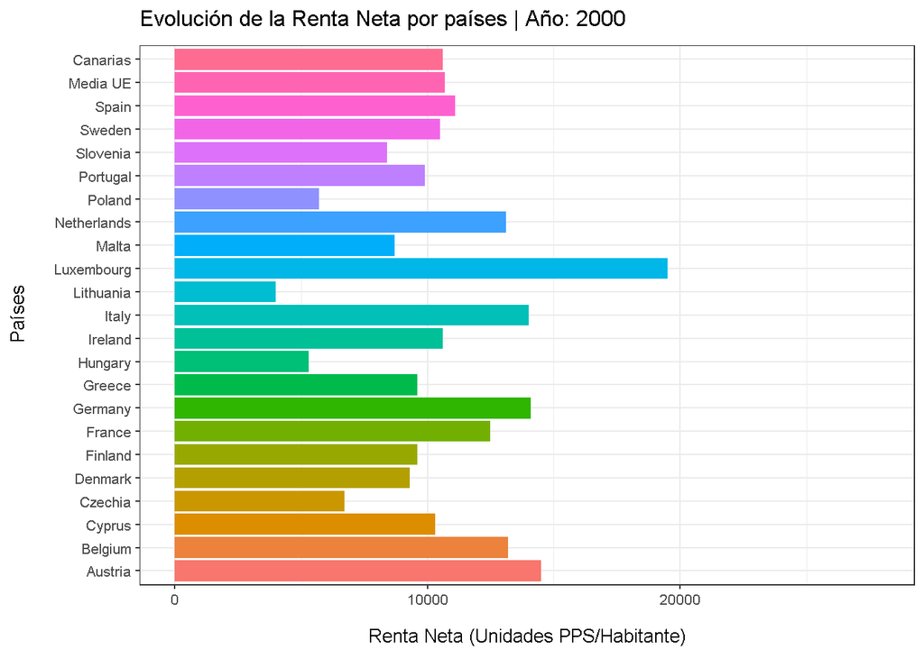

**Luxemburgo es un caso atípico** que distorsiona las métricas macroeconómicas de renta per cápita, lo cual es importante para interpretar cualquier resultado:

- **Centro Fiscal**: Gran parte de la renta contable se genera por los beneficios de empresas multinacionales y los flujos financieros que se registran en el país por motivos fiscales.
- **Efecto de Denominador**: Al ser un país pequeño, cuando estos flujos de capital se dividen por una población relativamente reducida, la cifra per cápita se dispara artificialmente, sin que este aumento refleje necesariamente el poder adquisitivo directo del trabajador promedio residente.

La alta renta alemana se sustenta en su potente base industrial y manufacturera.

- **Valor Añadido Bruto** (VAB): El enfoque en la ingeniería, la automoción de alta gama y la química asegura que la producción nacional genere un VAB elevado.
- **Estabilidad**: Esta estructura de exportación de bienes de capital proporciona una fuente de ingresos nacionales estable y constante, lo que se traslada a salarios altos y, por ende, a una renta disponible por habitante consistentemente superior a la media.

Continuemos viendo la evolución económica de los países, en este caso vamos a echar un vistazo a la **evolución del ingreso primario neto**, es decir, los ingresos brutos per cápita de cada país medidos en unidades PPS. Dado que Europa tiene muchos países, en este caso mostraremos los países más interesantes a comparar con España.

Ilustraremos esto con un gráfico de líneas.

[interactive chart not shown]

En general con este gráfico llegamos a las mismas conclusiones que antes pero, sin embargo, este nos permite más enforcanos que valores toma España con respecto a la **media de la Unión Europea**, vemos con claridad que hasta antes de la crisis del 2008 España se situaba por encima de esta y que después de dicha crisis **no consigue recuperase de la misma manera que la media** a pesar de que la tendencia sigue siendo ascendente.

Y bueno ya que venimos viendo la evolución del ingreso primario neto (ingreso bruto), puede ser interesante ver en cada país la **intervención del Estado sobre este ingreso primario**, es decir, **cuánto dinero pierde o gana un hogar después de que el Estado aplica impuestos y devuelve beneficios (prestaciones sociales recibidas)**, para este caso también incluiremos a **Canarias** junto con los países.

Para cuantificar y visualizar el impacto de la intervención del Estado en el ingreso de los hogares, se utiliza la Renta Disponible Neta, la cual, por definición en las cuentas nacionales, es el resultado final después de aplicar impuestos y transferencias sociales.

Es crucial entender que la Renta Disponible Neta ya incorpora las prestaciones sociales recibidas y otros beneficios, y por tanto, no es necesario incluirlas en la fórmula de cálculo.

- Si el resultado es **POSITIVO** (Ingreso Primario > Renta Neta): El país es un **Pagador Neto** (El Estado quita más de lo que devuelve).
- Si el resultado es **NEGATIVO** (Ingreso Primario < Renta Neta): El país es un **Receptor Neto** (El Estado devuelve más de lo que quita).

[interactive chart not shown]

El gráfico de Efecto Neto de la Redistribución Fiscal muestra una clara y pronunciada polarización económica en Europa, revelando la diferencia entre el **Ingreso Primario** y la **Renta Disponible.**

El resultado evidencia que las economías se dividen en dos grandes grupos:

- **Pagadores Netos (Contribuyentes):** Los países del Norte y Centro de Europa (Dinamarca, Países Bajos, Luxemburgo y Alemania) son los mayores contribuyentes netos, con un hogar promedio que cede entre 8.000€ y 10.000€ al Estado después de impuestos y transferencias. Esta fuerte presión fiscal refleja la financiación de robustos Estados de Bienestar y la alta recaudación.
- **Receptores Netos (Asistencia):** En contraste, las economías del Sur y del Este de Europa (incluyendo Grecia, Polonia, Portugal, Chipre y Bulgaria) se sitúan cerca del valor cero o son receptores netos, lo que indica que las prestaciones y transferencias sociales que reciben sus hogares son casi iguales o superiores a los impuestos que pagan.

**España** se sitúa como un contribuyente neto moderado, lejos de las cifras de cabeza, pero todavía con una contribución positiva, mientras que las regiones periféricas y más débiles (como Canarias en la lista) son, en esencia, fiscalmente neutrales.

En la gráfica anterior, vimos el saldo final de la intervención del Estado, identificando qué países eran contribuyentes netos (Pagadores Netos) y cuáles dependían más de las ayudas sociales (Receptores Netos).

Ahora, para entender mejor la magnitud de la diferencia que genera ese saldo, nos centraremos en la salida de recursos obligatoria que soporta cada hogar.

Para calcular esta carga fiscal directa sobre el ingreso, sumamos dos componentes clave que restan directamente de la renta de las familias: los **Impuestos Corrientes sobre Renta y Patrimonio** y las **Cotizaciones Sociales Netas**.

Este mapa de calor nos permitirá visualizar qué países y regiones tienen la mayor presión sobre el ingreso per cápita, la cual es necesaria para sostener sus respectivos sistemas de bienestar.

[interactive chart not shown]

El mapa de calor de la **Presión Fiscal Directa** revela una nítida polarización entre la Europa del Norte y la del Este, lo cual confirma la solidez de los Estados de Bienestar en las regiones más ricas.

El dato curioso es que esta visualización confirma que los países con la mayor presión fiscal (**Dinamarca, Países Bajos**) son precisamente los que resultaron ser Pagadores Netos en el análisis anterior, demostrando que la magnitud de la recaudación es la que dicta el saldo fiscal final.

Hemos analizado la presión fiscal directa sobre el ingreso de los hogares, que es el coste necesario para financiar los sistemas de bienestar y Cotizaciones. Ahora, es el momento de examinar el resultado final de esa riqueza generada y la capacidad de inversión.

Por último, cerramos el apartado con una visión geográfica y detallada del último año de datos (2022). Usaremos dos mapas coropléticos a nivel de regiones NUTS 2 para ver cómo se distribuyen la **Renta Disponible Neta** y la **Inversión en Activos Fijos,** lo que nos permitirá extraer conclusiones específicas sobre los focos geográficos de mayor riqueza y dinamismo económico en Europa, utilizaremos unidades PPS para el caso de la Renta Neta y euros por habitante para el caso de la Inversión en Activos Fijos, ya que no tenemos datos con unidades PPS. Filtraremos los mapas de manera que solo nos aparezcan las regiones para las que hay valores.

[interactive chart not shown]

De este primer mapa podemos sacar las siguientes conclusiones:

- **El Eje Central de Riqueza:** La renta disponible más alta (tonos rojos) se concentra claramente en el eje central de Europa (el ‘Arco de la Riqueza’): el sureste del Reino Unido (Londres), Benelux, el oeste y sur de Alemania (Baden-Württemberg, Baviera) y Escandinavia. Esto confirma que los países con la mayor presión fiscal directa son los que también tienen la mayor renta per cápita.
- **Disparidad Extrema:** Existe un fuerte clivaje (división) Norte-Oeste/Sur-Este. La renta cae drásticamente en todo el Sur (Italia, Portugal, Grecia) y en los países de la ampliación oriental, que están en el rango más bajo (tonos amarillos).
- **Efecto Capital:** Las capitales y los centros financieros (París, Dublín, Praga, Viena) se destacan como islas de alta renta (puntos rojos oscuros), reflejando la concentración de servicios de alto valor añadido.
- **Caso de España:** España muestra una notable disparidad intra-nacional. Mientras que regiones como Madrid y el País Vasco se sitúan en el rango medio-alto de la UE, la mayor parte del territorio, especialmente Andalucía y Extremadura, se encuentra en el rango medio-bajo, alineado con el sur de Italia. Esto confirma la disparidad estructural regional interna de España.

[interactive chart not shown]

Este segundo mapa revela que la inversión productiva se concentra en un eje muy específico de Europa Occidental y Central, que está desvinculado de la distribución de la renta disponible.

- **Foco de Capitalización:** Los niveles de inversión más altos (tonos rojos intensos) se concentran en el tradicional “Cinturón Industrial” que abarca Francia, el norte de Italia (el principal foco), y el sur de Alemania/Austria.
- **Disparidad con la Renta:** A diferencia del mapa de renta, donde Italia y Francia tenían niveles intermedios, aquí muestran la mayor intensidad de inversión. Esto sugiere que, si bien la renta disponible per cápita en estos países es menor que en Holanda o Dinamarca, el capital productivo se está inyectando con mayor fuerza en sus bases industriales.
- **Caso Español:** España y Portugal se encuentran consistentemente en el rango bajo a medio (tonos amarillos y naranjas claros), lo que indica un **atraso estructural en la inversión productiva** en comparación con el núcleo industrial de la Eurozona.

Todas este análisis realizado en este apartado se encuentra desarrollado en mayor profundidad en el **cuadro de mandos** del proyecto, ahí se permite una mayor exploración en profundidad de las distintas variables y las distintas regiones.

## Modelado

En este apartado haremos un análisis utilizando algunos modelos matemáticos que nos permitirán realizar predicciones y medir relaciones entre las distintas variables.

Al igual que en el anterior apartado, este análisis irá desde dentro de España hacia afuera.

Empezaremos el análisis visualizando una predicción hasta 2030 de la evolución de la renta neta en euros per cápita por las diferentes Comunidades Españolas. Para una mayor precisión filtraremos a partir del año 2002 ya que fue cuando se introdujo el euro a España.

Para este caso concreto, vamos a utilizar un gráfico estático, esto se justifica ya que de la otra manera no aparecen los intervalos de confianza y son un elemento demasiado importante para suprimirlo.

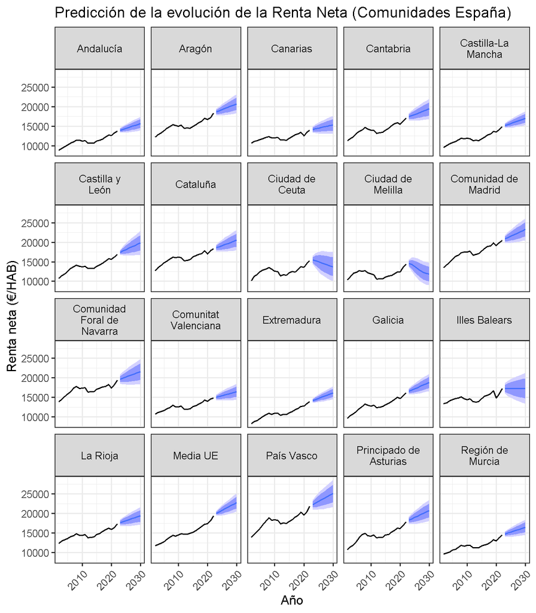

- **El Norte se distancia**: Las regiones con mayor renta base (País Vasco, Navarra y Madrid) presentan una pendiente de crecimiento robusta y constante, consolidando su liderazgo y alejándose del promedio nacional.
- **Convergencia Lenta**: La mayoría de comunidades (Castilla y León, Aragón, Cataluña) mantienen una tendencia positiva pero moderada, alineada con la media nacional.
- **Rezago Estructural**: Regiones como Extremadura, Canarias y Andalucía, aunque crecen, lo hacen a un ritmo insuficiente para cerrar la brecha con el norte, perpetuando la disparidad territorial observada en el análisis histórico.
- **La Anomalía de Ceuta y Melilla (Decrecimiento)**: El dato más alarmante lo arrojan las ciudades autónomas. A diferencia del resto del país, el modelo predice un estancamiento o ligero decrecimiento de la renta per cápita. Esto sugiere un desacople estructural preocupante: mientras la península se recupera, estas economías, condicionadas por su especificidad fronteriza y demográfica, no logran sumarse a la inercia de crecimiento general, ampliando drásticamente la brecha de desigualdad.

Tras identificar las marcadas disparidades geográficas tanto en la renta disponible como en la inversión productiva, es fundamental profundizar en la estructura subyacente de la economía regional europea. Para ello, aplicamos un **Análisis de Componentes Principales (PCA)** con el objetivo de reducir la dimensionalidad de los múltiples indicadores económicos y sociales. Este análisis nos permitirá determinar qué combinaciones de variables explican mejor la varianza entre las regiones, identificando si existe un patrón común que agrupe a las regiones ricas frente a las rezagadas, y qué peso tienen factores como los salarios, las prestaciones sociales o la inversión en dicha diferenciación.

Para realizar este análisis vamos generar un atributo combinado formado por el indicador económico y su dirección de flujo, es decir, si ha sido pagado, recibido, o es el resultado de un balance, hacemos esto ya que hay atributos con más de una dirección de flujo.

Primero veremos un gráfico de barras que nos mostrará que porcentaje de la **dispersión de los datos** explica cada componente y luego graficaremos la primera componente (eje x) y la segunda componente (eje y) para poder tener una visualización de dichas componentes.

[interactive chart not shown]

El gráfico de sedimentación revela una estructura de datos altamente redundante, donde el **primer componente principal (PC1)** domina de manera abrumadora, capturando el **64.8%** de la varianza total. Esto indica que la gran mayoría de las diferencias económicas entre las comunidades autónomas se pueden explicar por un único factor latente, muy probablemente relacionado con el **tamaño y la riqueza general** de la economía regional.

El segundo y tercer componente (PC2 y PC3) aportan un 11.2% y 10.7% respectivamente, sugiriendo matices adicionales (posiblemente relacionados con la estructura del mercado laboral o la especialización sectorial). Sin embargo, a partir del PC4, la varianza explicada cae drásticamente por debajo del 5%, lo que confirma que con solo los tres primeros componentes (que suman casi el **87%** de la información) podemos obtener una representación muy fiel de la realidad socioeconómica regional, simplificando enormemente el análisis multivariante.

[interactive chart not shown]

La proyección de las comunidades en el plano definido por el PC1 (Eje X: Tamaño y Riqueza) y el PC2 (Eje Y: Estructura de Bienestar) revela tres clústeres diferenciados:

- **El Polo de Poder Económico (Derecha):** **Madrid y País Vasco** se sitúan en el extremo derecho positivo del PC1, seguidos por **Cataluña e Islas Baleares**. Esto confirma que son los motores económicos de España, con los valores más altos en casi todos los indicadores absolutos (Renta, Inversión, PIB).
- **El Eje Industrial y de Bienestar (Centro-Derecha):** **Navarra, La Rioja y Aragón** ocupan una posición destacada, no solo en riqueza (PC1 alto), sino también diferenciados en el PC2, lo que sugiere una estructura de ingresos y bienestar particular, posiblemente ligada a su régimen foral y tejido industrial.
- **La Periferia Dependiente (Izquierda):** Regiones como **Extremadura, Castilla-La Mancha y las Ciudades Autónomas** se agrupan en el lado negativo del PC1. Su posición indica una menor magnitud económica y una mayor dependencia relativa de las transferencias sociales frente a la generación de rentas primarias. Vemos que regiones como **Canarias, Galacia o Cantabria** se sitúan más en el Centro-Izquierda.

Es decir, el eje horizontal (PC1) actúa como un claro gradiente de **desarrollo económico**, ordenando a las comunidades desde las economías más subsidiadas hacia las más productivas y dinámicas.

Después de este breve análisis, vamos a pasar a analizar **España** como país conjunto.

Para empezar vamos a ver una predicción hasta 2030 de la evolución de la **renta neta per cápita** en España. En este caso también veremos una **descomposición STL** de la serie temporal a la que aplicamos el modelo ARIMA. Para una mayor precisión filtraremos a partir del año 2002 ya que fue cuando se introdujo el euro a España.

[interactive chart not shown]

Consolidando el análisis a nivel nacional, el modelo ARIMA para **España** proyecta una **recuperación robusta y sostenida** hasta 2030. Tras la caída abrupta de 2020 y su posterior rebote en “V”, la tendencia central (línea azul) sugiere que la renta neta per cápita superará holgadamente los máximos históricos previos a la crisis financiera, acercándose a los **19.000€.**

Sin embargo, la notable apertura del **intervalo de confianza** (zona sombreada) a medida que nos alejamos en el tiempo advierte de una **incertidumbre macroeconómica creciente.** Aunque la inercia es positiva, la volatilidad del contexto global podría condicionar la magnitud final de este crecimiento.

[interactive chart not shown]

El análisis de descomposición de la serie temporal permite aislar los componentes estructurales de la renta neta española.

- **Tendencia (Trend):** El componente de tendencia es el dominante, mostrando una **trayectoria ascendente clara y suave** a largo plazo. A pesar de las crisis, la inercia subyacente de la renta es de crecimiento continuo, lo que valida la robustez de la recuperación estructural.
- **Residuo (Remainder):** El panel inferior revela las **perturbaciones de origen externo**. Se observan picos negativos muy marcados que coinciden con los grandes shocks económicos: la crisis financiera (2011-2013) y el impacto de la pandemia (2020). Estos residuos de gran magnitud confirman que las caídas de renta no fueron cambios de tendencia estructural, sino eventos puntuales de alta volatilidad que el modelo ARIMA debe absorber.

Una vez proyectada la senda de recuperación de la renta neta, es imprescindible analizar la contrapartida fiscal que acompaña a este crecimiento. Dado que el sistema tributario español es progresivo y que la renta disponible depende directamente de la capacidad recaudatoria del Estado para sostener los servicios públicos, el siguiente paso lógico es modelar la evolución esperada de la **presión fiscal directa.** A continuación, aplicamos el mismo modelo predictivo ARIMA para estimar cómo evolucionará la carga de **Impuestos sobre la Renta y el Patrimonio** que soportarán los hogares españoles en el próximo lustro.

Al igual que antes, filtraremos a partir del año 2002 ya que fue cuando se introdujo el euro a España y además veremos una descomposición STL de la serie temporal a la que se aplica el modelo ARIMA.

[interactive chart not shown]

La proyección para los **Impuestos sobre la Renta y Patrimonio** dibuja un escenario de **crecimiento sostenido y proporcional** a la recuperación económica general.

- **Tendencia Estructural:** El modelo anticipa una subida constante de la recaudación per cápita, proyectando superar los **3.500€ por habitante** hacia 2030. Esta trayectoria alcista replica la pendiente observada en la renta neta, lo que sugiere un sistema fiscal estable que captura riqueza al mismo ritmo que esta se genera, sin indicios de un endurecimiento desproporcionado de la presión fiscal en el modelo actual.
- **Recuperación en “V”:** Tras la caída de 2020, la recuperación de los ingresos tributarios es rápida y robusta, marcando nuevos máximos históricos ya en el corto plazo. Esto confirma la eficacia de los estabilizadores automáticos y la resiliencia de la base imponible española.
- **Incertidumbre a Largo Plazo:** El abanico del intervalo de confianza (95%) se abre significativamente a partir de 2025. Esto refleja que, aunque la inercia es de crecimiento, la cifra final dependerá de factores externos (inflación, tipos de interés) y de posibles reformas normativas que el modelo puramente estadístico no puede anticipar.

[interactive chart not shown]

Ya que hemos realizado una predicción sobre renta neta e impuestos, puede ser interesante sumar a dichos impuestos sobre renta y patrimonio el total de salarios y cotizaciones sociales pagadas por los empleadores para tener una mejor estimación sobre la presión fiscal y **ver la relación** de esta con la renta neta por países, ambas variables medidas en euros per cápita.

Esto lo veremos mediante un diagrama de dispersión utilizando un **modelo de regresión lineal** y además aplicando una **transformación yeojohnson** sobre la variable del eje y (Renta Neta) y tomaremos el último año de las observaciones (2022).

[interactive chart not shown]

El gráfico revela una **correlación positiva muy fuerte** y lineal: en Europa, disfrutar de una mayor renta disponible va intrínsecamente ligado a soportar una mayor carga fiscal. No hay países “ricos y baratos”; el bienestar se paga.

**Puntos Clave y Curiosidades:**

- **La Anomalía Danesa: Dinamarca** es el caso más llamativo. Se sitúa muy por encima de la línea de tendencia, lo que indica un **esfuerzo fiscal extraordinario.** A niveles de renta similares a Alemania o Austria, un danés paga mucho más. Esto se debe a su modelo de bienestar único, financiado casi exclusivamente por impuestos directos a la renta en lugar de cotizaciones patronales invisibles.
- **El Equilibrio Español: España** aparece justo sobre la línea de regresión, en la zona media. Esto desmiente la idea de anomalía: la presión fiscal que soportan los hogares españoles ($~6.000\text{€}$) es **matemáticamente consistente con su nivel de renta** ($~17.000\text{€}$). España recauda exactamente lo que se espera para una economía de su tamaño en el contexto europeo.
- **La Brecha Estructural:** Existe una clara polarización. Mientras que el bloque de Europa del Este (Bulgaria, Rumanía) apenas alcanza los $2.000\text{€}$ de contribución fiscal (limitando su capacidad de gasto público), las economías centrales (Bélgica, Alemania) triplican o cuadruplican esa cifra, permitiéndose servicios públicos mucho más robustos. La riqueza genera la base imponible necesaria para el Estado del Bienestar.

Por último, tras haber visto un diagrama de dispersión para ver la relación entre dos variables, hagamos una **matriz de correlación** utilizando un atributo combinado formado por la variable económica y su dirección de flujo para ver como se relacionan en general todas las variables entre países en el año 2022.

[interactive chart not shown]

La matriz de correlación revela una estructura económica altamente interconectada, dominada por un **bloque central de correlaciones positivas muy fuertes (>0.9)** entre los principales agregados macroeconómicos. Esto indica que el **tamaño y la riqueza de la economía son los factores determinantes:** los países con mayor Ingreso Primario también tienen sistemáticamente mayor Renta Disponible, Ahorro Neto, Gasto Final e Inversión. Es decir, la escala económica dicta la magnitud de todos estos flujos.

**El Ciclo del Bienestar (Renta-Impuestos-Prestaciones):**

- Existe una correlación casi perfecta (**0.96**) entre el **Ingreso Primario** y los **Impuestos Pagados.** Esto confirma la progresividad fiscal a nivel macroeconómico: las economías que generan más riqueza primaria son las que más recaudan para financiar el estado.
- A su vez, estos Impuestos tienen una correlación altísima (**0.96**) con las **Prestaciones Sociales Recibidas.** Esto evidencia el funcionamiento del sistema de redistribución: la alta recaudación se traduce directamente en un alto retorno social a los hogares.

**La Paradoja de las Prestaciones Pagadas:**

- Las **Prestaciones Sociales Pagadas** (es decir, las que salen de los hogares, no las que reciben) muestran una **correlación negativa débil (-0.23 a -0.29)** con todos los indicadores de riqueza. Esto sugiere que en las economías más ricas, los hogares no son los principales pagadores directos de estas prestaciones (probablemente financiadas por empresas o estado), o que este flujo es contra-cíclico respecto a la riqueza general.

**Inversión y Ahorro:**

- La **Inversión Fija** y el **Ahorro Neto** tienen una correlación perfecta (**1.0**) con la Renta Disponible. Esto implica que la capacidad de inversión y ahorro de un país no depende de factores culturales o preferencias, sino que es una función directa y lineal de su nivel de renta disponible: más renta disponible se traduce matemáticamente en mayor inversión y ahorro agregado.

En **conclusión**, el mapa de calor valida un modelo económico europeo cohesivo donde la generación de riqueza primaria impulsa simultáneamente la capacidad fiscal, el gasto social y la inversión productiva y por tanto es normal que en su mayoría las variables estén correlacionadas de manera que cuando una aumenta las demás por lo general también lo hacen ya que así funciona la economía.

Todo este análisis realizado se encuentra desarrollado en mayor detalle en el **cuadro de mandos** del proyecto, permitiendo ahí una mayor exploración en profundidad por los diferentes años, indicadores y regiones.

## Evaluación

En esta fase, evaluamos la robustez y la capacidad explicativa de los modelos matemáticos aplicados durante la fase de modelado, determinando si los resultados obtenidos constituyen una representación fiel de la realidad económica analizada.

#### Análisis Multivariante y Reducción de Dimensionalidad

Los resultados obtenidos mediante la **Matriz de Correlación** y el **Análisis de Componentes Principales (PCA)** confirman la existencia de una fuerte estructura de dependencia lineal entre las variables económicas estudiadas.

El hecho de que el **primer componente principal (PC1)** sea capaz de capturar por sí solo más del **60% de la varianza total**, y que los tres primeros componentes expliquen conjuntamente más del **80%**, evidencia una alta redundancia en los datos originales. Esto valida la hipótesis de que la complejidad económica de las regiones puede reducirse eficazmente a unas pocas dimensiones latentes (principalmente relacionadas con el tamaño de la economía y el bienestar), simplificando la interpretación sin pérdida significativa de información.

#### Modelado de Relaciones (Regresión Lineal)

Finalmente, la evaluación del modelo de regresión lineal entre la **Renta Neta per Cápita** y la **Presión Fiscal** (tras la aplicación de la transformación Yeo-Johnson para corregir la asimetría) arroja resultados concluyentes. El coeficiente de determinación obtenido ($R^2 = 0.88$) indica una **bondad de ajuste excelente**, confirmando estadísticamente que la presión fiscal es una función directa y predecible de la renta disponible en el contexto europeo. Este alto nivel de correlación refuerza la solidez de las conclusiones extraídas sobre la estructura fiscal de los países analizados.

## Despliegue

La fase de despliegue se materializa a través de la elaboración de la presente memoria técnica y el desarrollo de un **Cuadro de Mandos Interactivo (Dashboard)**. Esta herramienta ha sido construida utilizando las librerías `flexdashboard` y `shiny` en R, y se encuentra desplegada públicamente en el **servidor Shiny del Departamento de Informática y Sistemas (DIS)**, garantizando su accesibilidad.

El cuadro de mandos se estructura en cinco pestañas temáticas, diseñadas para cubrir desde el análisis exploratorio hasta la modelización predictiva:

- **Series Temporales:** Esta sección permite visualizar la evolución de los indicadores económicos en el periodo **2000-2022**, ofreciendo un análisis comparativo tanto a nivel de país (NUTS 0) como regional (NUTS 2). La interfaz es altamente reactiva:
  - **Controles Dinámicos:** Los selectores de *país*, *región* e *indicador* se actualizan automáticamente según la disponibilidad de datos y la unidad seleccionada. Además, se filtra el listado de indicadores para mostrar solo aquellos disponibles para la unidad métrica escogida.
  - **Normalización de Datos:** Se han implementado funciones reactivas para transformar los valores absolutos a valores *per cápita*, permitiendo comparaciones justas. Debido a la escasez de datos en unidades de poder adquisitivo (PPS) a nivel regional y a la homogeneidad de precios dentro de un mismo país, el análisis regional se restringe exclusivamente a **Euros por habitante (EUR_HAB)**.
  - **Funcionalidades Avanzadas:** Se incluye una opción de “Seleccionar Todo” para facilitar la carga masiva de regiones, así como la posibilidad de activar escalas libres en los ejes. Destaca la capacidad de comparar regiones específicas (como Canarias) directamente con el agregado de la **Unión Europea** o con la media nacional, integrando estas entidades en los selectores para un análisis de convergencia directo. Se incluye una tabla de datos filtrados al pie de la visualización.
- **Atributos por Año:** Centrada en la visualización geoespacial mediante **mapas coropléticos**. Permite el filtrado multidimensional (país, región, indicador y año). Al igual que en la sección anterior, se aplica una lógica de normalización para presentar datos *per cápita*. La interfaz discrimina la disponibilidad de unidades, restringiendo el análisis regional a euros corrientes por la limitación de datos PPS. Una tabla adjunta complementa la visualización espacial con los valores numéricos exactos.
- **Comparación de Atributos:** Esta pestaña implementa un análisis bivariante mediante **diagramas de dispersión**, permitiendo estudiar la correlación entre dos variables económicas seleccionadas por el usuario a partir de un año base.
  - **Transformación de Variables:** Para mejorar el ajuste de los modelos de regresión lineal subyacentes, se permite aplicar transformaciones matemáticas a los ejes (raíz cuadrada, logarítmica o Yeo-Johnson).
  - **Unidad de Medida:** El análisis se realiza exclusivamente en euros *per cápita* debido a la mayor robustez y disponibilidad de datos frente al PPS. Los datos se normalizan automáticamente antes de la visualización.
  - Se acompaña de una tabla lateral con los datos resultantes del filtrado.
- **Predicción con ARIMA:** Dedicada a la prospectiva económica, esta sección utiliza modelos **ARIMA** para proyectar la evolución de indicadores seleccionados.
  - **Parametrización:** El usuario puede definir el año de inicio de la serie, el horizonte de predicción y los parámetros del modelo (p,d,q), buscando optimizar los intervalos de confianza.
  - **Alcance:** Permite la comparación simultánea de hasta dos entidades geográficas. Se ha habilitado la inclusión de **Canarias** y el agregado de la **Unión Europea** tanto en los selectores nacionales como regionales para facilitar comparativas de convergencia.
  - **Restricciones:** Al igual que en las series temporales, el análisis regional fuerza el uso de euros por habitante debido a la consistencia de los datos. La interfaz se adapta dinámicamente para impedir selecciones inválidas.
- **Análisis de Atributos (Multivariante):** Esta pestaña ofrece una visión global de la estructura de los datos para un año seleccionado, permitiendo filtrar por nivel administrativo (NUTS 0 o NUTS 2). Se estructura en sub-secciones analíticas:
  1. **Tabla de Datos:** Muestra los valores brutos. Todos los atributos se presentan normalizados (*per cápita*) y en euros, priorizando la disponibilidad de datos para maximizar el número de observaciones útiles para el análisis de reducción de dimensionalidad.
  2. **Matriz de Correlación:** Visualiza la intensidad de las relaciones lineales entre las variables seleccionadas.
  3. **Estandarización y PCA:** Se incluye una vista de los datos estandarizados y el cálculo de los **Componentes Principales (PCA)**.
  4. **Visualización PCA:** Dos pestañas finales muestran el porcentaje de varianza explicada por cada componente (gráfico de sedimentación) y la proyección de las observaciones en los nuevos ejes (Biplot/Scatterplot), facilitando la identificación de patrones y clústeres regionales.

# Conclusiones y trabajo futuro

## Conclusiones

El análisis realizado ha permitido diseccionar la estructura económica de los hogares europeos y españoles, validando la hipótesis de que los promedios nacionales (NUTS 0) son insuficientes para comprender la realidad del bienestar económico. A la luz de los objetivos planteados, se extraen las siguientes conclusiones empíricas:

- **1. La Convergencia Interrumpida y la Brecha Este-Oeste**

El análisis de series temporales evidencia que la convergencia de **España** con el núcleo rico de la UE (Alemania, Benelux, Austria) se fracturó tras la crisis de 2008. Asimismo, la visualización espacial mediante **mapas coropléticos** confirma una marcada desigualdad estructural en el continente: existe una frontera económica visible que divide a Europa. A pesar de que economías emergentes del Este (como Polonia) muestran pendientes de crecimiento aceleradas, en términos de **renta disponible** absoluta sigue existiendo un desfase significativo respecto al bloque occidental, perpetuando una “Europa a dos velocidades” donde la riqueza se concentra en un eje central industrial. Además, los datos históricos nos dicen que esta desigualdad va en aumento en lugar de disminuir, siendo que con el paso de los años la diferencia en términos de renta neta por regiones es mayor.

- **2. La Fractura Interna: El caso de la “España divergente”**

Al descender al nivel NUTS 2, se confirma una dualidad estructural en España. Las regiones de **Madrid, País Vasco y Navarra** presentan métricas de renta y ahorro alineadas con la media-alta europea, actuando como motores de tracción. En contraste, **Canarias, Andalucía y Extremadura** permanecen en un rezago crónico.Un hallazgo crítico del modelado ARIMA es la proyección preocupante para las Ciudades Autónomas (**Ceuta y Melilla**), donde, a diferencia de la inercia de crecimiento del resto del país, se prevé un estancamiento o decrecimiento real, señalando un riesgo de desacople económico severo. Además, el diagrama de dispersión por comunidades autónomas que relaciona la renta neta y el ahorro, muestra claramente que a lo largo de los años los países se separan más unos de otros, lo que quiere decir que esta desigualdad, al igual que en el caso de Europa, va en aumento.

- **3. Fiscalidad como Consecuencia de la Riqueza**

El modelo de regresión lineal ($R^2 = 0.88$) aplicado sobre los datos de 2022 desmiente la noción de una presión fiscal desproporcionada en España. Los datos sitúan a España exactamente sobre la línea de regresión: la carga fiscal soportada ($\text{D5} + \text{D61}$) es matemáticamente consistente con su nivel de renta neta.El análisis comparativo revela que los mayores niveles de bienestar (Dinamarca, Países Bajos) están intrínsecamente ligados a una presión fiscal muy superior ($> 8.000\text{€}$/hab), necesaria para sostener sus sistemas de protección social, mientras que España se mantiene en un punto de equilibrio medio ($~6.000\text{€}$/hab).

- **4. Redundancia de Variables (PCA)**

El Análisis de Componentes Principales demostró que la complejidad económica regional es reducible: el **64.8% de la varianza** entre regiones se explica por un solo factor latente (riqueza/tamaño). Esto implica que variables aparentemente distintas (Renta, Ahorro, Inversión) se mueven en bloque: no hemos encontrado regiones “pobres con alta inversión” o “ricas con bajo ahorro”; el desarrollo es sistémico.

#### Limitaciones del Estudio

Es necesario reconocer las restricciones que condicionan el alcance de estas conclusiones:

- **Sesgo por falta de paridad de poder adquisitivo (PPS):** La indisponibilidad de datos en unidades PPS para variables clave como la **Inversión** o el **Ahorro** obliga a usar Euros corrientes. Esto subestima el esfuerzo real de inversión en las economías de Europa del Este, donde el coste de la vida es menor, y podría estar magnificando la brecha visual con los países nórdicos.
- **Ceguera ante la desigualdad interna:** Al trabajar con medias per cápita (incluso en NUTS 2), el estudio asume una distribución homogénea de la riqueza dentro de cada región. No se ha podido determinar si el crecimiento de la renta en regiones como Madrid beneficia al conjunto de la población o si se concentra en los deciles superiores (coeficiente de Gini).
- **Modelado Univariante:** Las predicciones ARIMA, aunque robustas en sus intervalos de confianza a corto plazo, se basan exclusivamente en la historia pasada de la variable. No incorporan choques exógenos futuros (cambios legislativos, crisis geopolíticas o energéticas), por lo que deben interpretarse como un escenario de “inercia” y no como una certeza absoluta.

## Trabajo futuro

La naturaleza iterativa de la metodología **CRISP-DM** implica que el final de un ciclo de análisis abre la puerta a nuevas preguntas y refinerías. A la luz de las limitaciones identificadas durante la fase de evaluación y el despliegue del modelo, se proponen las siguientes líneas de investigación y mejora para futuras iteraciones del proyecto:

#### 1. Profundización en la Estructura Fiscal (Impuestos Indirectos)

El análisis actual de la presión fiscal se ha limitado a los impuestos directos ($\text{D5}$) y cotizaciones ($\text{D61}$). Una extensión crítica sería la incorporación de los **Impuestos sobre la producción y las importaciones** ($\text{D2}$), que incluyen el IVA. Dado que estos impuestos tienen un carácter regresivo y afectan directamente al consumo, su inclusión permitiría calcular la **Carga Fiscal Total** real que soportan los hogares, ofreciendo una visión más holística de la pérdida de poder adquisitivo tras la intervención estatal.

#### 2. Descenso a la Granularidad NUTS 3 (Análisis Intra-regional)

Si bien el nivel NUTS 2 ha permitido visibilizar la brecha entre Comunidades Autónomas, este promedio aún enmascara realidades locales dispares. Se propone descender al nivel **NUTS 3 (provincias e islas)**. Esta ampliación sería especialmente relevante para el caso de **Canarias**, permitiendo un análisis de la “doble insularidad” para determinar si la riqueza y la renta se distribuyen equitativamente entre las islas capitalinas y las no capitalinas.

#### 3. Homogeneización del Coste de Vida (Expansión de Datos PPS)

Una limitación recurrente ha sido la escasez de datos en unidades de **Estándar de Poder Adquisitivo (PPS)** para indicadores secundarios (como el Ahorro o la Inversión), obligando al uso de Euros nominales. Un trabajo futuro indispensable es la búsqueda de fuentes complementarias o el cálculo manual de factores de conversión PPS para **todas las variables monetarias.** Esto eliminaría el sesgo de precios entre países del Este y del Norte de Europa, refinando las conclusiones sobre el esfuerzo de ahorro y la inversión real.

#### 4. Modelado Multivariante (Mejora de Predicciones)

Los modelos **ARIMA** utilizados son univariantes (se basan solo en el pasado de la propia variable). Para reducir la incertidumbre observada en los intervalos de confianza a largo plazo, se propone la implementación de **modelos de regresión dinámica (ARIMAX)** o Modelos de Vectores Autorregresivos (VAR). Estos permitirían incluir variables exógenas predictoras, como la tasa de desempleo, la inflación o el crecimiento del PIB nacional, para afinar las proyecciones de renta neta.

#### 5. Análisis de Desigualdad Interna

Finalmente, el estudio se ha basado en medias per cápita. Una extensión valiosa sería incorporar indicadores de distribución, como el **Coeficiente de Gini** o el ratio S80/S20 regional. Esto permitiría discernir si un aumento en la Renta Disponible per Cápita se traduce en un bienestar generalizado o si, por el contrario, responde a una concentración de la riqueza en los deciles más altos de la población regional.

## Anexo. Seguimiento temporal actividades del proyecto

TOTAL HORAS TRABAJADAS EN EL PROYECTO : 66.09

[interactive chart not shown]

**DESGLOSE DETALLADO DE LAS SESIONES DE TRABAJO**

|  | START | END | MINUTES | ACTIVITY | FINAL COMMENT |
| --- | --- | --- | --- | --- | --- |
| 1 | 2025-09-24T11:45:21Z | 2025-09-24T12:34:31Z | 49.2 | Compresión del negocio | Elección y comprobación de requisitos de dataset |
| 2 | 2025-09-25T10:11:36Z | 2025-09-25T11:03:55Z | 52.3 | Comprensión de los datos | Redacción del modelo de validación y entrega |
| 3 | 2025-10-05T20:26:49Z | 2025-10-05T22:32:08Z | 125.3 | Comprensión de los datos | Redacción de la memoria del proyecto correspondiente a esta parte |
| 4 | 2025-10-07T12:15:31Z | 2025-10-07T12:25:20Z | 9.8 | Compresión del negocio | Redacción de la memoria del proyecto |
| 5 | 2025-10-08T09:41:06Z | 2025-10-08T09:56:10Z | 15.1 | Otros | Corrección de errores y estética en la memoria del proyecto |
| 6 | 2025-10-14T10:44:47Z | 2025-10-14T11:11:28Z | 26.7 | Comprensión de los datos | He añadido el código correspondiente a cada sección del apartado 'Comprensión de los datos'. |
| 7 | 2025-10-14T11:17:59Z | 2025-10-14T13:28:30Z | 130.5 | Preparación de los datos | He hecho 4 gráficas, haciendo comparaciones tanto a nivel nacional como regional. Además he filtrado datos de la tabla y transformado variables para un mejor análisis, por último he incluido una colum… |
| 8 | 2025-10-15T12:31:20Z | 2025-10-15T13:38:37Z | 67.3 | Modelado | He obtenido unos primeros resultados y predicciones sobre la renta y los impuestos en España |
| 9 | 2025-10-15T13:38:51Z | 2025-10-15T13:55:14Z | 16.4 | Preparación de los datos | He añadido otra gráfica que hace comparaciones sobre el nivel de impuestos que se paga en los distintos países. |
| 10 | 2025-10-16T15:48:57Z | 2025-10-16T16:35:50Z | 46.9 | Otros | He añadido un chunk con lenguaje css para que al compilar el RMD como HTML, la memoria se vea mejor. También he añadido espacios para mejorar la legibilidad en el apartado de compresión de los datos. |

[output cut: 60 more lines]